# Plot assignment

Template: Ian Hussey; content: Emilie

2024-01-14

# Dependencies

```r
library(tidyverse)
library(ggplot2)
```

# Get Data

The data set utilized for the plot was downloaded from osf.io. As such, it is the final data set of the study “Is video games’ effect on attitudes universal? Results from an empirical study comparing video games impact on the attitude change of players with different backgrounds” by Kolek et al. (2023). The authors investigate whether a video game has an impact on explicit and implicit attitudes. Based on the available data set, it was possible to detect a shift on the explicit attitudes.

```r
data_video_games_raw <- read_csv("../data/raw/cs3_2_final_data_without_age.csv") |>
janitor::clean_names()
```

# Sources

- Link to the article: https://onlinelibrary.wiley.com/doi/10.1111/jcal.12911
- Link to the dataset: https://osf.io/f23cb

# Modifications to dataset

Some modifications have been applied to the dataset in order to visualize certain aspects within the plot. It is important to note that these modifications may not correspond to those intended by the authors and therefore may not represent the exact variables.

```r
data_video_games_processed <- data_video_games_raw |>
  rename(Pretest_PANAS_Negative = pre_pana_sn,
         Pretest_PANAS_Positive = pre_pana_sp,
         Posttest_PANAS_Negative = post_pana_sn,
         Posttest_PANAS_Positive = post_pana_sp) |>
  mutate(education = case_when(
    education == "S" ~ "Secondary Education",
    education == "Z" ~ "University",
    TRUE ~ education ),
    group = case_when(
    group == "C" ~ "Control Group",
    group == "E" ~ "Experimental Group",
    TRUE ~ group))
```

## Write the modifications to Disk

```r
# in case this dir doesn't exist it is created
dir.create("../data/processed/")

# save data to disk in that dir
write_csv(data_video_games_processed, "../data/processed/data_video_games_processed.csv")
```

# Good Plot

The PANAS (Positive and Negative Affect Schedule) is a questionnaire that is widely used to measure mood or emotions. It is based on a 5-point Likert scale measuring the positive or negative affect on a total score ranging between 10 and 50. The higher scores on the positive scale represent a more positive affect and the higher sores on the negative scale represent a more negative affect. A comparison of the mean values between the positive and negative scales both before and after the respective exposure is graphically displayed. This allows to recognize as to whether the exposure influences the affective states within the test subjects. It is important that the experimental and control groups are separated in order to assess whether and to what extent the different exposures exert an effect. Given that the median is shown within the boxplot instead of the mean, a point is inserted into the plot to represent the average score.

# Good Plots

## PANAS Positive

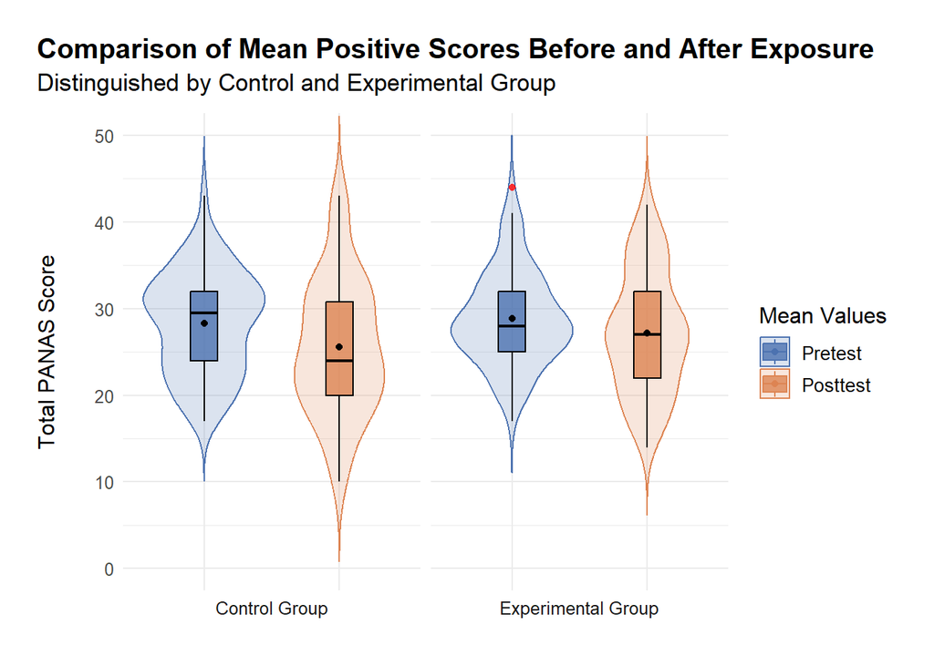

```r
#Create a df
Positive_data_long <- data_video_games_processed |>
  select(group, Pretest_PANAS_Positive, Posttest_PANAS_Positive) |>
  pivot_longer(cols = c(Pretest_PANAS_Positive, Posttest_PANAS_Positive),
               names_to = "Test_Type",
               values_to = "Positive_Score")

# Manually calculating the mean values
mean_values_positive <- Positive_data_long |>
  group_by(group, Test_Type) |>
  summarise(Positive_mean_score = round(mean(Positive_Score, na.rm = TRUE), digits = 2), .groups = "drop") #Drop the grouping in order to have no warning when plotting the data later.


# Set the dodge width in order to prevent overlapping and control the space between the Pre- and Posttest within plot
dodge_width <- 0.8

#In vizualisation we want to have pretest before posttest, which is why we explicitly set this
Positive_data_long$Test_Type <- factor(Positive_data_long$Test_Type, levels = c("Pretest_PANAS_Positive",
                                                                                "Posttest_PANAS_Positive"))

#Create a plot
Plot_Positive <- ggplot(Positive_data_long,
                        aes(x = interaction(group, Test_Type), #In order to be able to include both informations in the plot we have to set an interaction.
                            y = Positive_Score,
                            fill = Test_Type,
                            color = Test_Type)) +
  geom_violin(trim = FALSE,
              alpha = 0.2) + #include violin distribution
  geom_boxplot(width = 0.2,
               size = 0.4,
               alpha = 0.8,
               color = "black",
               outlier.shape = 16,
               outlier.color = "red",
               position = position_dodge(width = dodge_width)) + #put the boxplot within the violin
  stat_summary(fun = mean, # since we are interested in the mean values we include them as a black dot within the plot
               geom = "point",
               color = "black",
               size = 1.5,
               position = position_dodge(width = dodge_width))  +
  labs(title = "Comparison of Mean Positive Scores Before and After Exposure", #Set title and undertitle
       subtitle = "Distinguished by Control and Experimental Group",
       x = NULL, #No further information provided which is why we leave it out
       y = "Total PANAS Score") +
  coord_cartesian(ylim = c(0, 50)) +
  scale_fill_manual(values = c("#4C72B0", "#DD8452"), name = "Mean Values", labels = c("Pretest", "Posttest")) + #set the colors
  scale_color_manual(values = c("#4C72B0", "#DD8452"), name = "Mean Values", labels = c("Pretest", "Posttest")) +
  theme_minimal() +
  guides(fill = guide_legend(override.aes = list(color = c("#4C72B0", "#DD8452"))), #Create the legends adjusted to the colors
         color = FALSE) +
  facet_wrap(~group, scales = "free_x",  #Put the labels control group and experimental group under the graphs
             ncol = 2,
             switch= "x") +
  theme(text = element_text(size = 12), #Adjust the plot overall appearance with margins and texts
        legend.position = "right",
        legend.title = element_text(size = 12),
        legend.text = element_text(size = 10),
        axis.title = element_text(size = 12),
        axis.title.y = element_text(size = 12, margin = margin(0, 20, 0, 0)),
        plot.title = element_text(size = 15, hjust = 0, margin = margin(b = 5), face = "bold"),
        plot.subtitle = element_text(size = 13, margin = margin(b = 10)),
        plot.title.position = "plot",
        plot.margin = margin(20, 20, 20, 20),
        axis.text.x = element_blank())  # Remove x labels as they provide no further information

print(Plot_Positive)
```

## PANAS Negative

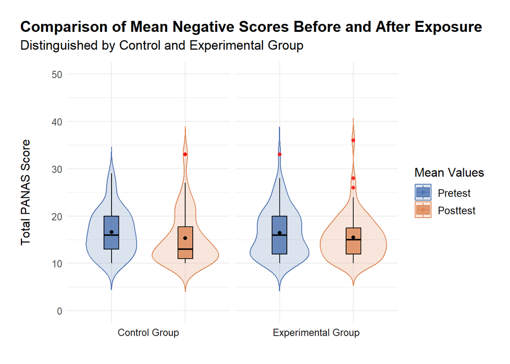

```r
#Create a df

Plot_Negative <-
Negative_data_long <- data_video_games_processed |>
  select(group, Pretest_PANAS_Negative, Posttest_PANAS_Negative) |>
  pivot_longer(cols = c(Pretest_PANAS_Negative, Posttest_PANAS_Negative),
               names_to = "Test_Type",
               values_to = "Negative_Score")

# Manually calculating the mean values
mean_values_negative <- Negative_data_long |>
  group_by(group, Test_Type) |>
  summarise(Negative_mean_score = round(mean(Negative_Score, na.rm = TRUE), digits = 2), .groups = "drop")

# Set the dodge width to prevent overlapping and control the space between the Pre- and Posttest within the plot
dodge_width <- 0.8

# In visualization, we want to have pretest before posttest, which is why we explicitly set this
Negative_data_long$Test_Type <- factor(Negative_data_long$Test_Type, levels = c("Pretest_PANAS_Negative",
                                                                                "Posttest_PANAS_Negative"))

# Create a plot. As it is the same plot as above just for the negative data there is no further information provided within the code here.
Plot_Negative <- ggplot(Negative_data_long,
                        aes(x = interaction(group, Test_Type),
                            y = Negative_Score,
                            fill = Test_Type,
                            color = Test_Type)) +
  geom_violin(trim = FALSE,
              alpha = 0.2) +
  geom_boxplot(width = 0.2,
               size = 0.4,
               alpha = 0.8,
               color = "black",
               outlier.shape = 16,
               outlier.color = "red",
               position = position_dodge(width = dodge_width)) +
  stat_summary(fun = mean,
               geom = "point",
               color = "black",
               size = 1.5,
               position = position_dodge(width = dodge_width))  +
  labs(title = element_text("Comparison of Mean Negative Scores Before and After Exposure", face = "bold"),
       subtitle = "Distinguished by Control and Experimental Group",
       x = NULL,
       y = "Total PANAS Score") +
  coord_cartesian(ylim = c(0, 50)) +
  scale_fill_manual(values = c("#4C72B0", "#DD8452"), name = "Mean Values", labels = c("Pretest", "Posttest")) +
  scale_color_manual(values = c("#4C72B0", "#DD8452"), name = "Mean Values", labels = c("Pretest", "Posttest")) +
  theme_minimal() +
  guides(fill = guide_legend(override.aes = list(color = c("#4C72B0", "#DD8452"))),
         color = FALSE) +
  facet_wrap(~group, scales = "free_x",
             ncol = 2,
             switch= "x") +
  theme(text = element_text(size = 12),
        legend.position = "right",
        legend.title = element_text(size = 12),
        legend.text = element_text(size = 10),
        axis.title = element_text(size = 12),
        axis.title.y = element_text(size = 12, margin = margin(0, 20, 0, 0)),
        plot.title = element_text(size = 15, hjust = 0, margin = margin(b = 5), face = "bold"),
        plot.subtitle = element_text(size = 13, margin = margin(b = 10)),
        plot.title.position = "plot",
        plot.margin = margin(20, 20, 20, 20),
        axis.text.x = element_blank())

print(Plot_Negative)
```

## Why are these good plots?

- The plots are clear and easy to read, unnecessary information is omitted and only the meaningful elements are referred to, thereby avoiding overplotting.
- The quality of the plots reflects the research interest, they clearly show the differences in the mean value and the distribution of the scores between the measurement points.
- A combination of boxplot, violin plot and illustration of the mean value is a good way of quickly gaining a statistical overview.
- The groups are displayed next to each other, which allows a direct comparison of each group with itself, and simultaneously with the other group. This way, each group can be analyzed individually or combined.
- Both plots are laid out in the same way, allowing them to be easily used for comparison.
- the legend is clearly marked in different colors to provide a quick overview. Furthermore, unnecessary axis labels or too much information are avoided in order to keep only necessary information within the plot.
- Title and subtitle indicate clearly what is to be shown graphically.
- The y axis is adjusted to the PANAS maximum score so that superfluous spacing can be reduced.
- The choice of colors, aesthetics and distances are set in such a way that a clear overall picture with sufficient spacing is created.

# Bad plot

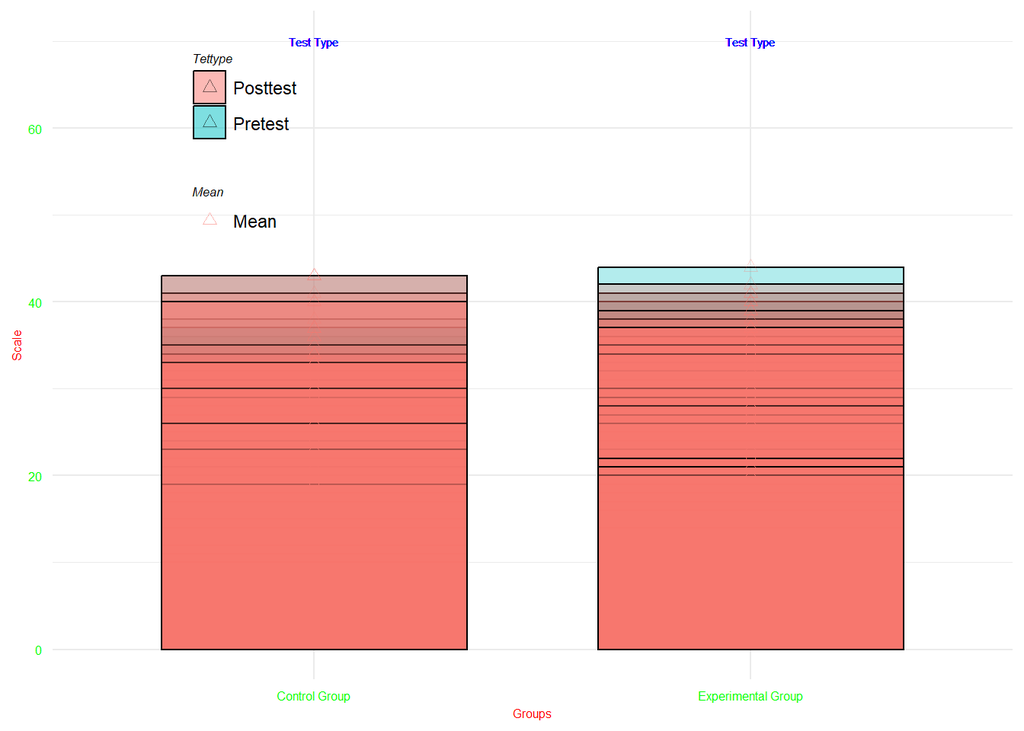

```r
Bad_Plot <- ggplot(data_video_games_processed,
                   aes(x = group,
                       y = Pretest_PANAS_Positive,
                       fill = "Pretest")) + #Plot two bar plots for each group but does not plot the Pre- and Posttests separately.
  geom_bar(stat = "identity",
           position = "dodge",
           width = 0.7,
           color = "black",
           alpha = 0.3) +
  geom_bar(stat = "identity",  #Bar for Posttest
           aes(x = group,
               y = Posttest_PANAS_Positive,
               fill = "Posttest"),
           position = "dodge",
           width = 0.7,
           color = "black",
           alpha = 0.3) +
   geom_point(aes(x = group, #Trying to include the mean
                 y = Posttest_PANAS_Positive,
                 color = "Mean"),
             position = position_dodge(width = 0.7),
             size = 2, alpha = 0.3,
             shape = 2) +
  geom_point(aes(x = group, #Mean inclusion for posttest
                 y = Pretest_PANAS_Positive,
                 color = "Mean"),
             position = position_dodge(width = 0.7),
             size = 2, alpha = 0.3,
             shape = 2) +
  geom_text(aes(x = group, #Adds a fixed label to the top that does not provide any further information
                y = 70,
                label = "Test Type"),
            position = position_dodge(width = 0.7),
            size = 2,
            alpha = 0.3,
            color = "blue") +
  labs(x = "Groups", #Add overall plot labels that do not provide clear information
       y = "Scale",
       color = "Mean",
       fill = "Tettype") +
  theme_minimal() +
  theme(legend.position = c(0.2, 0.8),  #Legend position
        legend.title = element_text(face = "italic", size = 6),
        axis.title = element_text(size = 6, color = "red"),
        axis.text = element_text(size = 6, color = "green"))

print(Bad_Plot)
```

# Write to disk

```r
#Positive Plot
ggsave(filename = "Good_Plot_Positive_PANAS_Emilie.pdf", plot = Plot_Positive, path = "../communications", width = 12, height = 8)

#Negative Plot
ggsave(filename = "Good_Plot_Negative_PANAS_Emilie.pdf", plot = Plot_Negative, path = "../communications", width = 12, height = 8)

#Bad Plot
ggsave(filename = "Bad_Plot_Emilie.pdf", plot = Bad_Plot, path = "../communications", width = 12, height = 8)
```